# DS Project 2

# Team:Jizhou Cheng,Kaiwen Fu, Ritvik Nadikude

Data Set Chosen for project: California Housing Prices Url for Data Set: https://www.kaggle.com/datasets/camnugent/california-housing-prices/

# Motivation/Relevance:

We have chosen this topic because as we all know in America and especially in California the cost of living is really high and we thought that it would be interesting to get to know more about the reality behing the California housing prices by analysing the data which we have got, henceforth we chose this topic and framed different questions and did coding to portray it in a graphical manner to make analysis easier! Hopefully this project makes sense and gives more clarity on the housing prices in California.

# Ease of Understanding:

This topic which we chose is like a general topic where every person has a connection to. Even though it is just done on California it lets people know the average cost of living in the bigger cities. We have made the project pretty easy to understand in the form of graphs and analysis with questions and codes!

# Question 1: What is the distribution of housing prices?

Code:

```
   longitude  latitude  housing_median_age  total_rooms  total_bedrooms  \
0    -122.23     37.88                41.0        880.0           129.0
1    -122.22     37.86                21.0       7099.0          1106.0
2    -122.24     37.85                52.0       1467.0           190.0
3    -122.25     37.85                52.0       1274.0           235.0
4    -122.25     37.85                52.0       1627.0           280.0

   population  households  median_income  median_house_value ocean_proximity
0       322.0       126.0         8.3252            452600.0        NEAR BAY
1      2401.0      1138.0         8.3014            358500.0        NEAR BAY
2       496.0       177.0         7.2574            352100.0        NEAR BAY
3       558.0       219.0         5.6431            341300.0        NEAR BAY
4       565.0       259.0         3.8462            342200.0        NEAR BAY
```

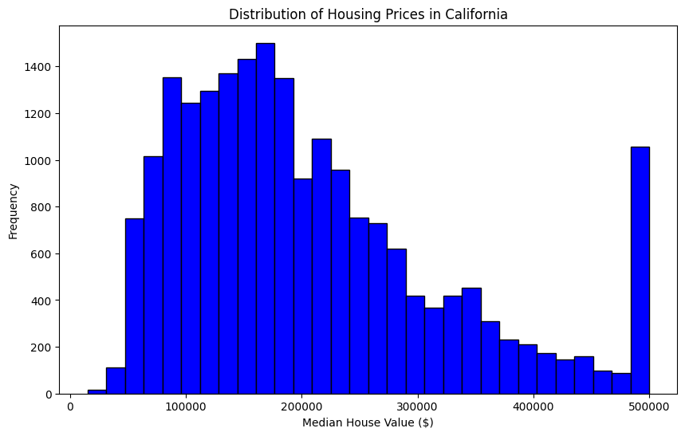

```python
import pandas as pd
import matplotlib.pyplot as plt

# Load the dataset (replace 'path_to_dataset' with the actual path to your CSV file)
housing_data = pd.read_csv('housing.csv')

# Display the first few rows of the dataset to understand its structure
print(housing_data.head())

# Question 1: What is the distribution of housing prices?
plt.figure(figsize=(10, 6))
plt.hist(housing_data['median_house_value'], bins=30, color='blue', edgecolor='black')
plt.title('Distribution of Housing Prices in California')
plt.xlabel('Median House Value ($)')
plt.ylabel('Frequency')
plt.show()
```